# Topic 7 Exercises: Nonlinear regression

## Question 7.9.3

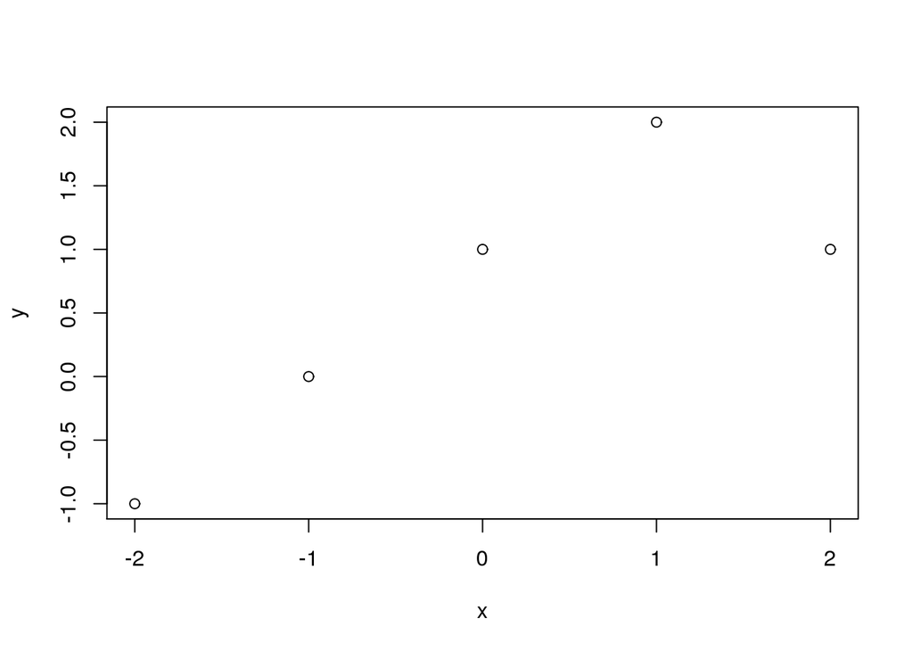

```r
x <- -2:2
y= 1+ x + -2 * (x-1)^2 * I(x>1)
plot (x,y)
```

When x goes from -2 to 1, the slope is linear which shows the equation y = 1+x. When x goes from 1 to 2, the curve is quadratic and has the equation: y= 1 + x-2(x-1)^2.

## Question 7.9.4

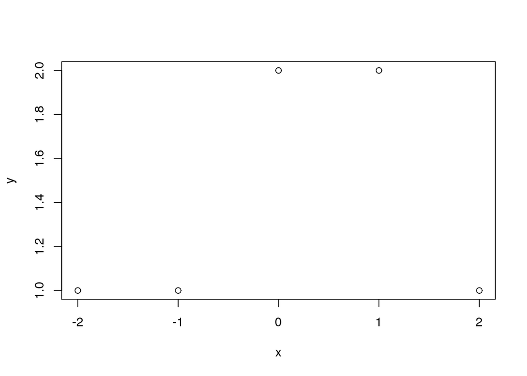

```r
x <- -2:2
y= c(1+ 0 + 0, # x = -2
     1+ 0 +0, # x = -1
     1+ 1 + 0, # x = 0
     1+ (1-0) + 0, # x = 1
     1+ (1-1) + 0 # x = 2
     )
plot(x,y)
```

From x = -2 to 1, it looks like a step-wise function because from -2 to 1 it’s constant lines. From x = -2 to -1, the equation would be y= 1 and from x= 0 to 1, the equation would be y= 2. From x=1 to 2, however, the curve is linear with the equation y= 3-x.

## Question 7.9.5

1. As lambda approaches infinity, g2 will have a smaller training RSS because g is raised to a higher number so it’ll be more flexible.
2. As lambda approaches infinity, g1 will have a smaller testing RSS because g2 would most likely overfit the data because it’s more flexible.
3. When lambda = 0, g1 and g2 would equal each other so they’ll have the same training and testing RSS.

## Question 7.9.11

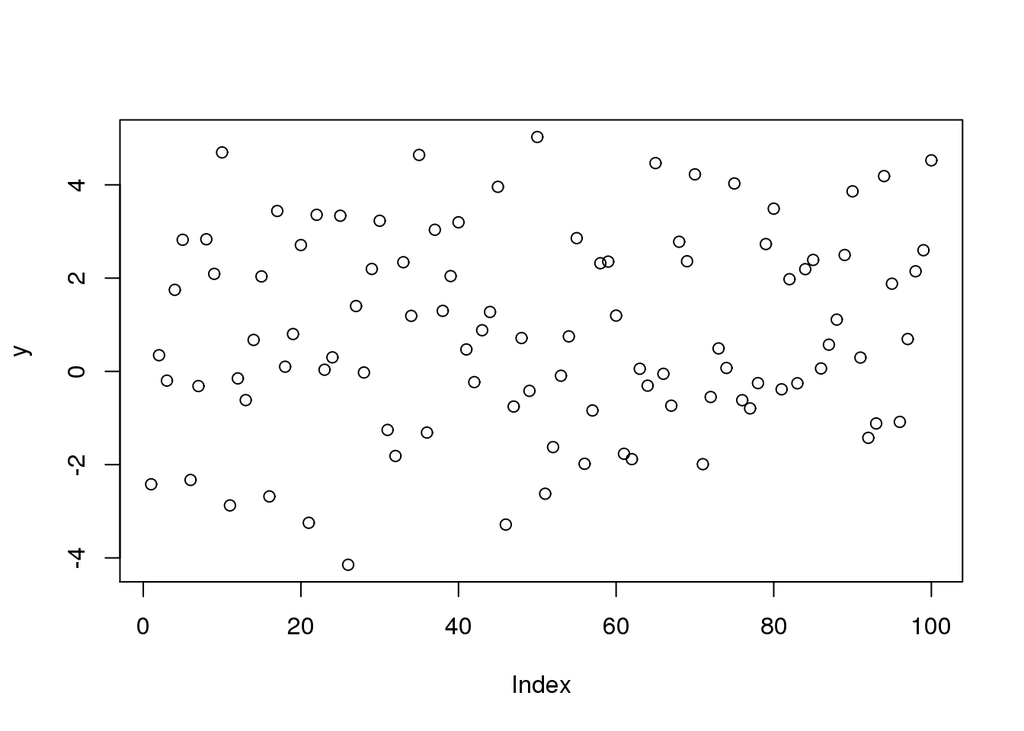

```r
x1 <- rnorm(100)
x2 <- rnorm(100)
b0 <- 1
b1 <- 1
b2 <- 1
eps <- rnorm(100, sd = 1)
y <- b0 + b1*x + b2*x2 + eps
plot(y)
```

```r
bh1 <- 2
```

```r
a <- y - bh1 * x1
beta2 <- lm(a~x2)$coef[2]
```

```r
bh2 <- 2
a<- y-bh2 * x2
beta1 <- lm(a~x1)$coef[2]
```

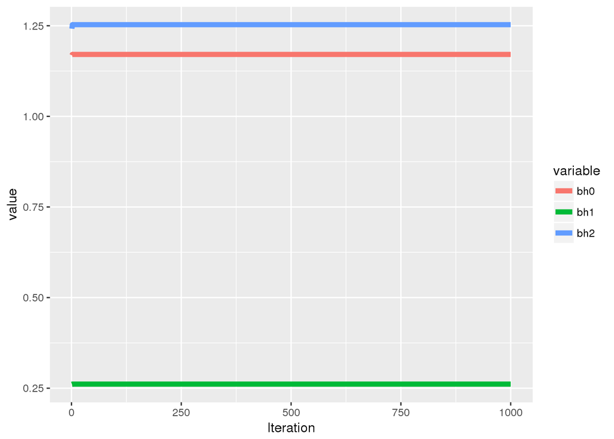

```r
bh0 <- bh1 <- bh2 <- rep(0, 1000)
for (i in 1:1000) {
  a <- y - bh1[i] * x1
  bh2[i] <- lm(a ~ x2)$coef[2]
  a <- y - bh2[i] * x2
  bh0[i] <- lm(a ~ x1)$coef[1]
  bh1[i+1] <- lm(a ~ x1)$coef[2]
}

require(ggplot2)
require(reshape2)
grp <- data.frame(Iteration = 1:1000, bh0, bh1=bh1[-1], bh2)
grp1 <- melt(grp, id.vars = "Iteration")

ggplot(grp1, aes(x= Iteration, y= value, group=variable, col = variable)) + geom_line(size = 2)
```

```r
mod <- lm(y ~ x1 + x2)
coef(mod)
```

```
## (Intercept)          x1          x2
##   1.1708840   0.2613011   1.2529868
```

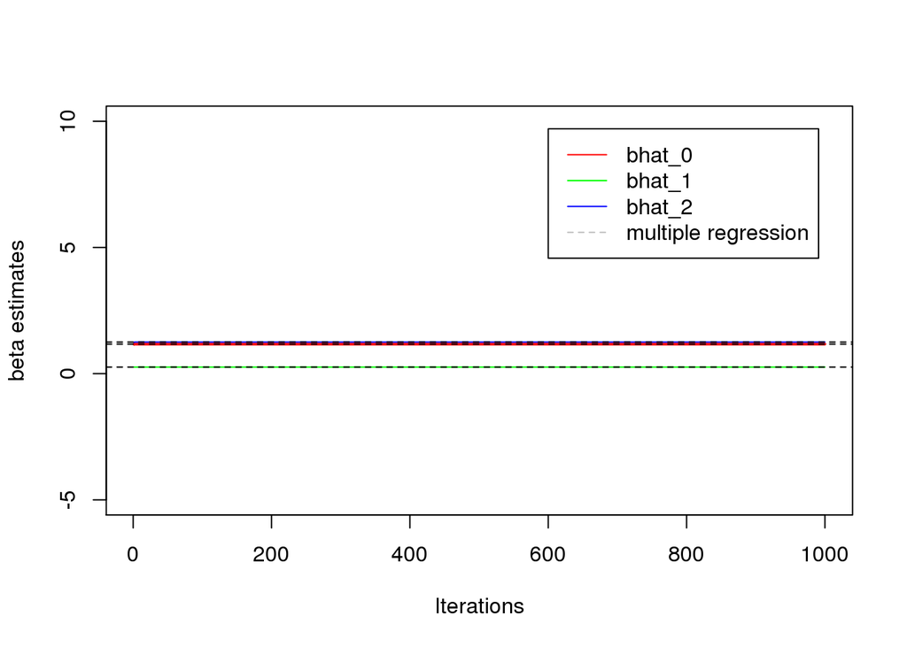

```r
plot(bh0, type="l", col="red", lwd=2, xlab="Iterations",
     ylab="beta estimates", ylim=c(-5,10))

lines(bh1[-1], col="green")
lines(bh2, col="blue")

abline(h=coef(mod)[1], lty="dashed")
abline(h=coef(mod)[2], lty="dashed")
abline(h=coef(mod)[3], lty="dashed")

legend(x=600,y=9.7, c("bhat_0", "bhat_1", "bhat_2", "multiple regression"),
       lty = c(1,1,1,2),
       col = c("red","green","blue","gray"))
```

```r
head(grp)
```

```
##   Iteration      bh0       bh1      bh2
## 1         1 1.168301 0.2608898 1.241844
## 2         2 1.170880 0.2613004 1.252969
## 3         3 1.170884 0.2613011 1.252987
## 4         4 1.170884 0.2613011 1.252987
## 5         5 1.170884 0.2613011 1.252987
## 6         6 1.170884 0.2613011 1.252987
```

One iteration is enough to get a decent fit because starting at the second iteration, the estimates are all the same.